# Analyzing Financial and Economic Data with R

Chapter 05 - Importing Data from the Internet

Marcelo S. Perlin

2020-02-15

# Introduction

In this chapter, I will describe and give examples of the most important and reliable packages for data importation in the fields of finance and economics:

**`GetQuandlData` [@GetQuandlData]**

Imports economical and financial data from the Quandl platform.

**`BatchGetSymbols` [@BatchGetSymbols]**

Imports adjusted and unadjusted stock price data from Yahoo Finance.

**`simfinR` [@simfinR]**

Imports financial statements and adjusted stock prices from the [SimFin project](https://simfin.com/)[^1].

**`tidyquant` [@tidyquant]**

Imports several financial information about stock prices and fundamental data.

**`Rbitcoin` [@Rbitcoin]**

Imports data for cryptocurrencies.

# Package `GetQuandlData`

*Quandl* is an established and comprehensive platform that provides access to a series of free and paid data. Several central banks and research institutions provide free economic and financial information on this platform.

I strongly recommend browsing the available tables from the [Quandl website](https://www.quandl.com/)[^2]. It is likely that you’ll find datasets that you’re familiar with.

The **first and mandatory** step in using `GetQuandlData` is to register a user at the [Quandl website](https://www.quandl.com/). Soon after, go to *account settings* and click *API KEY*. This page should show a code, such as `Esv7Ac7zuZzJSCGxynyF`. Copy it to the clipboard (*control + c*) and, in R, define a character object containing the copied content as follows:

```r
# set FAKE api key to quandl
my_api_key <- 'Esv7Ac7zuZzJSCGxynyF'
```

```r
library(GetQuandlData)
library(tidyverse)
# set symbol and dates
my_symbol <- c('Gold Prices in EURO' = 'WGC/GOLD_DAILY_USD')
first_date <- as.Date('1980-01-01')
last_date <- as.Date('2019-01-01')

# get data!
df_gold <- get_Quandl_series(id_in = my_symbol,
                             api_key = my_api_key,
                             first_date = first_date,
                             last_date = last_date)

# check it
glimpse(df_gold)
```

```
## Observations: 10,474
## Variables: 4
## $ series_name <chr> "Gold Prices in EURO", "Gold Prices in EURO", "Gold Price…
## $ ref_date    <date> 2020-02-21, 2020-02-20, 2020-02-19, 2020-02-18, 2020-02-…
## $ value       <dbl> 1643.30, 1619.00, 1604.20, 1589.85, 1580.80, 1581.40, 157…
## $ id_quandl   <chr> "WGC/GOLD_DAILY_USD", "WGC/GOLD_DAILY_USD", "WGC/GOLD_DAI…
```

As an inspection check, let’s plot the prices of Gold in USD over time. Here we will use the package `ggplot2` to create the figure. For now, you don’t need to worry about the plotting code, because we have chapter @ref(figures), which is fully dedicated to this topic.

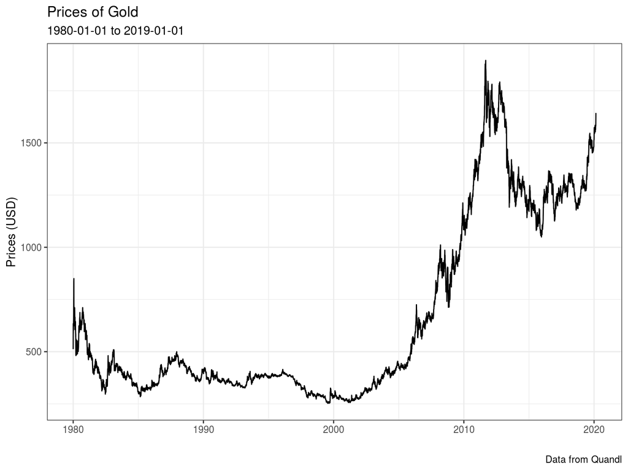

```r
library(ggplot2)

# plot prices with ggplot2
p <- ggplot(df_gold, aes(x = ref_date, y = value)) +
  geom_line() +
  labs(y = 'Prices (USD)',
       x = '',
       title = 'Prices of Gold',
       subtitle = paste0(first_date, ' to ', last_date),
       caption = 'Data from Quandl') +
   theme_bw()

# print it
print(p)
```

Overall, gold prices were fairly stable between 1980 and 2000, reaching a spike after 2010. One possible explanation is the higher demand for safer assets, such as gold, after the 2009 financial crisis.

#### Fetching many time series

When asking for multiple time series from Quandl, package `GetQuandlData` stacks all the data in a single `dataframe`, making it easier to work with the `tidyverse` tools. As an example, let’s look at `Quandl` database `RATEINF`, which contains a time series of inflation rates around the world. First, we need to see what are the available datasets:

```r
library(GetQuandlData)
library(tidyverse)

# databse to get info
db_id <- 'RATEINF'

# get info
df_db <- get_database_info(db_id, my_api_key)

glimpse(df_db)
```

```
## Observations: 26
## Variables: 8
## $ code         <chr> "CPI_ARG", "CPI_AUS", "CPI_CAN", "CPI_CHE", "CPI_DEU", "…
## $ name         <chr> "Consumer Price Index - Argentina", "Consumer Price Inde…
## $ description  <chr> "Please visit <a href=http://www.rateinflation.com/infla…
## $ refreshed_at <dttm> 2020-02-22 02:03:48, 2020-02-22 02:03:48, 2020-02-22 02…
## $ from_date    <date> 1988-01-31, 1948-09-30, 1989-01-31, 1983-01-31, 1991-01…
## $ to_date      <date> 2013-12-31, 2019-12-31, 2020-01-31, 2020-01-31, 2020-01…
## $ quandl_code  <chr> "RATEINF/CPI_ARG", "RATEINF/CPI_AUS", "RATEINF/CPI_CAN",…
## $ quandl_db    <chr> "RATEINF", "RATEINF", "RATEINF", "RATEINF", "RATEINF", "…
```

Column `name` contains the description of tables. If we dig deeper, we’ll find the following names:

```r
print(unique(df_db$name))
```

```
##  [1] "Consumer Price Index - Argentina"   "Consumer Price Index - Australia"
##  [3] "Consumer Price Index - Canada"      "Consumer Price Index - Switzerland"
##  [5] "Consumer Price Index - Germany"     "Consumer Price Index - Euro Area"
##  [7] "Consumer Price Index - France"      "Consumer Price Index - UK"
##  [9] "Consumer Price Index - Italy"       "Consumer Price Index - Japan"
## [11] "Consumer Price Index - New Zealand" "Consumer Price Index - Russia"
## [13] "Consumer Price Index - USA"         "Inflation YOY - Argentina"
## [15] "Inflation YOY - Australia"          "Inflation YOY - Canada"
## [17] "Inflation YOY - Switzerland"        "Inflation YOY - Germany"
## [19] "Inflation YOY - Euro Area"          "Inflation YOY - France"
## [21] "Inflation YOY - UK"                 "Inflation YOY - Italy"
## [23] "Inflation YOY - Japan"              "Inflation YOY - New Zealand"
## [25] "Inflation YOY - Russia"             "Inflation YOY - USA"
```

```r
selected_series <- c('Inflation YOY - USA',
                     'Inflation YOY - Canada',
                     'Inflation YOY - Euro Area',
                     'Inflation YOY - Australia')

# filter selected countries
idx <- df_db$name %in% selected_series
df_db <- df_db[idx, ]
```

Now we grab the data using `get_Quandl_series`:

```r
my_id <- df_db$quandl_code
names(my_id) <- df_db$name
first_date <- '2010-01-01'
last_date <- Sys.Date()

df_inflation <- get_Quandl_series(id_in = my_id,
                                  api_key = my_api_key,
                                  first_date = first_date,
                                  last_date = last_date)

glimpse(df_inflation)
```

```
## Observations: 121
## Variables: 4
## $ series_name <chr> "Inflation YOY - Canada", "Inflation YOY - Canada", "Infl…
## $ ref_date    <date> 2020-01-31, 2019-12-31, 2019-11-30, 2019-10-31, 2019-09-…
## $ value       <dbl> 2.4, 2.2, 2.2, 1.9, 1.9, 1.9, 2.0, 2.0, 2.4, 2.0, 1.9, 1.…
## $ id_quandl   <chr> "RATEINF/INFLATION_CAN", "RATEINF/INFLATION_CAN", "RATEIN…
```

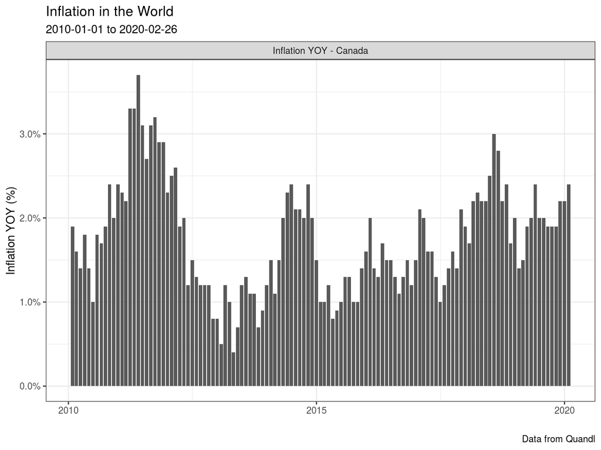

```r
p <- ggplot(df_inflation, aes(x = ref_date, y = value/100)) +
  geom_col() +
  labs(y = 'Inflation YOY (%)',
       x = '',
       title = 'Inflation in the World',
       subtitle = paste0(first_date, ' to ', last_date),
       caption = 'Data from Quandl') +
  scale_y_continuous(labels = scales::percent) +
  facet_wrap(~series_name) +
  theme_bw()

print(p)
```

As you can see, the `GetQuandlData` output is formatted to work well with the `tidyverse` tools.

# Package `BatchGetSymbols`

Package `BatchGetSymbols` [@BatchGetSymbols] is all about downloading stock price data from Yahoo Finance.

- **Cleanliness and organization**
- **Control of import errors**
- **Comparison of dates to a benchmark**
- **Caching system**
- **Access to *tickers* in market indices**
- **Use of multiple cores**
- **Flexible output format**

As an example of usage, let’s download the prices of four stocks in the previous five years using function `BatchGetSymbols`.

```r
library(BatchGetSymbols)

# set tickers
tickers <- c('MSFT','GOOGL','JPM','GE')

# set dates
first_date <- Sys.Date()-5*365
last_date <- Sys.Date()
thresh_bad_data <- 0.95   # sets percent threshold for bad data
bench_ticker <- '^GSPC'   # set benchmark as ibovespa
cache_folder <- 'BGS_Cache' # set folder for cache

l_out <- BatchGetSymbols(tickers = tickers,
                         first.date = first_date,
                         last.date = last_date,
                         bench.ticker = bench_ticker,
                         thresh.bad.data = thresh_bad_data,
                         cache.folder = cache_folder)
```

Back to our example, object `l_out` has two elements, a table called `df.control` and another table called `df.tickers`. We can access each element using operator `$`, such as in `l_out$df.control`. The first table, `df.control`, contains the result of the download process. As previously mentioned, the package not only downloads the data but also keeps track of possible errors and missing values. Let’s check the content of this table.

```r
# print result of download process
print(l_out$df.control)
```

```
## # A tibble: 4 x 6
##   ticker src   download.status total.obs perc.benchmark.dates threshold.decision
##   <chr>  <chr> <chr>               <int>                <dbl> <chr>
## 1 MSFT   yahoo OK                   1257                    1 KEEP
## 2 GOOGL  yahoo OK                   1257                    1 KEEP
## 3 JPM    yahoo OK                   1257                    1 KEEP
## 4 GE     yahoo OK                   1257                    1 KEEP
```

Column `threshold.decision` from `df.control` shows that all tickers were valid, and we got 1257 valid observations (rows) for each company.

As for the actual financial data, it is contained in element `df.tickers` of `l_out`. Let’s have a look:

```r
# print df.tickers
glimpse(l_out$df.tickers)
```

```
## Observations: 5,028
## Variables: 10
## $ price.open          <dbl> 44.13, 43.67, 43.56, 43.01, 43.07, 43.00, 42.19, …
## $ price.high          <dbl> 44.20, 44.19, 43.83, 43.21, 43.24, 43.11, 43.13, …
## $ price.low           <dbl> 43.66, 43.55, 43.09, 42.88, 42.82, 42.15, 42.19, …
## $ price.close         <dbl> 43.85, 43.88, 43.28, 43.06, 43.11, 42.36, 42.85, …
## $ volume              <dbl> 33807700, 31924000, 31748600, 25748700, 23193500,…
## $ price.adjusted      <dbl> 39.53887, 39.56593, 39.02491, 38.82653, 38.87163,…
## $ ref.date            <date> 2015-02-27, 2015-03-02, 2015-03-03, 2015-03-04, …
## $ ticker              <chr> "MSFT", "MSFT", "MSFT", "MSFT", "MSFT", "MSFT", "…
## $ ret.adjusted.prices <dbl> NA, 0.0006843139, -0.0136739618, -0.0050832153, 0…
## $ ret.closing.prices  <dbl> NA, 0.0006842190, -0.0136737007, -0.0050831332, 0…
```

As expected, we find information about stock prices and traded volume. Notice it also includes column `ticker`, which contains the symbols of the stocks. In the tidy format, each stock has a chunk of data that is pilled in top of each other. Later, in chapter @ref(programming), we will use this column to split the data and build summary tables.

To inspect the data, let’s look at its prices with `ggplot2`.

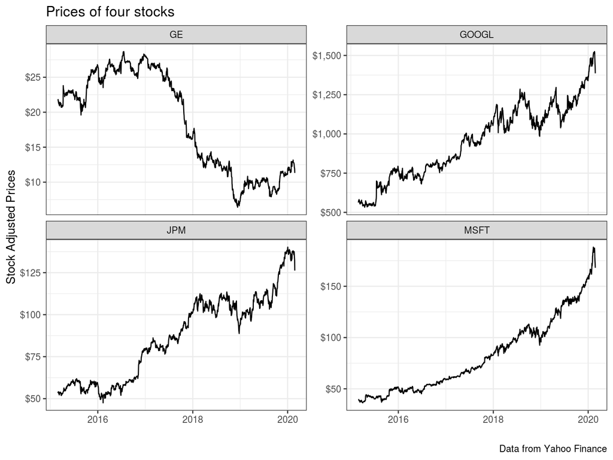

```r
library(ggplot2)

p <- ggplot(l_out$df.tickers, aes(x = ref.date,
                                  y = price.adjusted)) +
  geom_line() + facet_wrap(~ticker, scales = 'free_y') +
  scale_y_continuous(labels = format.cash) +
  labs(x = '',
       y = 'Stock Adjusted Prices',
       title = 'Prices of four stocks',
       caption = 'Data from Yahoo Finance') +
  theme_bw()

print(p)
```

We see that General Eletric (GE) stock was not kind to its investors. Someone that bought the stock at its peak in mid-2016 has found its current value at less than half. Now, when it comes to the GOOGL, JPM and MSFT, we see an upward increase in stock prices. These are profitable and competitive companies in their sectors and not surprisingly, the stock prices surged over time.

# Package `simfinR`

[SimFin](https://simfin.com/)[^3] is a special project for making financial data as accessible as possible. It works by gathering data from different stock exchanges and financial reports, cleaning and verifying it against official records, and distributing the tables from an API (*access point interface*.). From its own website:

> Our core goal is to make financial data as freely available as possible because we believe that having the right tools for investing/research shouldn’t be the privilege of those that can afford to spend thousands of dollars per year on data.

Package `simfinR` facilitates importing data from the SimFin API. First, it makes sure the requested data exists and only then calls the api.

### Example 01 - Apple Inc Annual Profit

The first step in using `simfinR` is registering at the [SimFin website](https://simfin.com/). Once done, click on [Data Access](https://simfin.com/data/access/api)[^4]. It should now show an API key such as `'rluwSlN304NpyJeBjlxZPspfBBhfJR4o'`. Save it in an R object for later use.

```r
my_api_key <- 'rluwSlN304NpyJeBjlxZPspfBBhfJR4o'
```

With the API key in hand, the second step is to find the numerical id of the company of interest. For that, we can find all available companies and their respective ids and ticker with `simfinR_get_available_companies`.

```r
library(simfinR)
library(tidyverse)

# get info
df_info_companies <- simfinR_get_available_companies(my_api_key)

# check it
glimpse(df_info_companies)
```

```
## Observations: 2,719
## Variables: 3
## $ simId  <int> 171401, 901704, 901866, 45730, 378251, 896477, 418866, 963384,…
## $ ticker <chr> "ZYXI", "ZYNE", "ZVO", "ZUMZ", "ZTS", "ZS", "ZNGA", "ZM", "ZIO…
## $ name   <chr> "ZYNEX INC", "Zynerba Pharmaceuticals, Inc.", "Zovio Inc", "Zu…
```

Digging deeper into the `dataframe`, we find that the numerical id of Apple is 111052. Let’s use it to download the annual financial information since 2009.

```r
id_companies <- 111052 # id of APPLE INC
type_statements <- 'pl' # profit/loss
periods = 'FY' # final year
years = 2009:2018

df_fin_FY <- simfinR_get_fin_statements(
  id_companies,
  type_statements = type_statements,
  periods = periods,
  year = years,
  api_key = my_api_key)
```

```
## Fetching data for companies: 111052
```

```
## Fetching data for years: 2009, 2010, 2011, 2012, 2013, 2014, 2015, 2016, 2017, 2018
```

```
## Periods: FY
```

```
##
## Making sure all company ids are available
```

```
##  - all good
```

```
##
## Start grabbing data
```

```
## Fetching data for APPLE INC (111052) | type=pl | period=FY | year=2009
```

```
##  Table found. Fetching it..
```

```
## Fetching data for APPLE INC (111052) | type=pl | period=FY | year=2010
```

```
##  Table found. Fetching it..
```

```
## Fetching data for APPLE INC (111052) | type=pl | period=FY | year=2011
```

```
##  Table found. Fetching it..
```

```
## Fetching data for APPLE INC (111052) | type=pl | period=FY | year=2012
```

```
##  Table found. Fetching it..
```

```
## Fetching data for APPLE INC (111052) | type=pl | period=FY | year=2013
```

```
##  Table found. Fetching it..
```

```
## Fetching data for APPLE INC (111052) | type=pl | period=FY | year=2014
```

```
##  Table found. Fetching it..
```

```
## Fetching data for APPLE INC (111052) | type=pl | period=FY | year=2015
```

```
##  Table found. Fetching it..
```

```
## Fetching data for APPLE INC (111052) | type=pl | period=FY | year=2016
```

```
##  Table found. Fetching it..
```

```
## Fetching data for APPLE INC (111052) | type=pl | period=FY | year=2017
```

```
##  Table found. Fetching it..
```

```
## Fetching data for APPLE INC (111052) | type=pl | period=FY | year=2018
```

```
##  Table found. Fetching it..
```

```r
glimpse(df_fin_FY)
```

```
## Observations: 580
## Variables: 13
## $ company_name   <chr> "APPLE INC", "APPLE INC", "APPLE INC", "APPLE INC", "A…
## $ company_sector <chr> "Computer Hardware", "Computer Hardware", "Computer Ha…
## $ type_statement <fct> pl, pl, pl, pl, pl, pl, pl, pl, pl, pl, pl, pl, pl, pl…
## $ period         <fct> FY, FY, FY, FY, FY, FY, FY, FY, FY, FY, FY, FY, FY, FY…
## $ year           <int> 2009, 2009, 2009, 2009, 2009, 2009, 2009, 2009, 2009, …
## $ ref_date       <date> 2009-12-31, 2009-12-31, 2009-12-31, 2009-12-31, 2009-…
## $ acc_name       <chr> "Revenue", "Sales & Services Revenue", "Financing Reve…
## $ acc_value      <dbl> 4.2905e+10, NA, NA, NA, -2.5683e+10, NA, NA, NA, 1.722…
## $ tid            <chr> "1", "3", "5", "6", "2", "7", "8", "9", "4", "10", "11…
## $ uid            <chr> "1", "0", "0", "0", "2", "0", "0", "0", "4", "10", "11…
## $ parent_tid     <chr> "4", "1", "1", "1", "4", "2", "2", "2", "19", "19", "1…
## $ display_level  <chr> "0", "1", "1", "1", "0", "1", "1", "1", "0", "0", "0",…
## $ check_possible <lgl> FALSE, FALSE, FALSE, FALSE, FALSE, FALSE, FALSE, FALSE…
```

And now we plot the results of the Net Income (profit/loss) for all years:

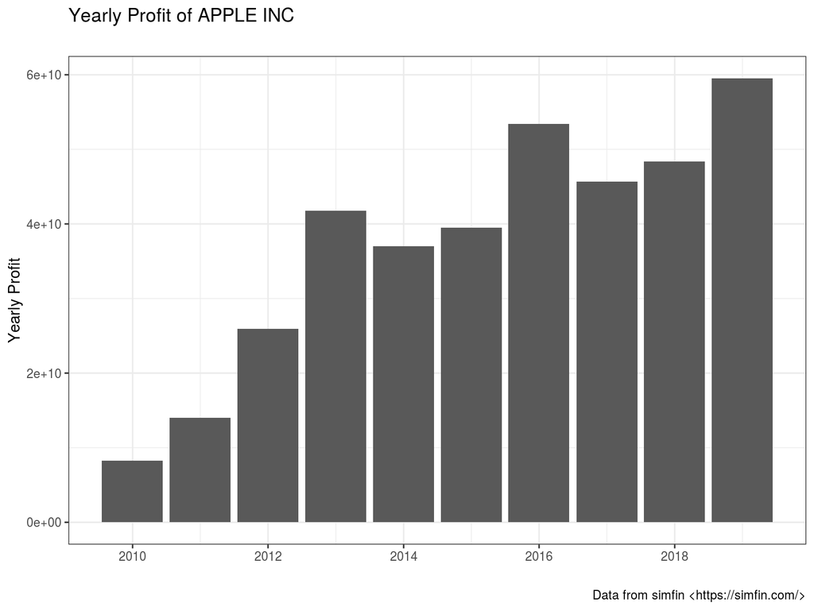

```r
net_income <- df_fin_FY %>%
              dplyr::filter(acc_name == 'Net Income')

p <- ggplot(net_income,
            aes(x = ref_date, y = acc_value)) +
  geom_col()  +
  labs(title = 'Yearly Profit of APPLE INC',
       x = '',
       y = 'Yearly Profit',
       subtitle = '',
       caption = 'Data from simfin <https://simfin.com/>') +
  theme_bw()

print(p)
```

Not bad! Apple has been doing very well over the years. We can also grab data for all quarters and get more detailed information:

```r
type_statements <- 'pl' # profit/loss
periods = c('Q1', 'Q2', 'Q3', 'Q4') # final year
years = 2009:2018

df_fin_quarters <- simfinR_get_fin_statements(
  id_companies,
  type_statements = type_statements,
  periods = periods,
  year = years,
  api_key = my_api_key)
```

```
## Fetching data for companies: 111052
```

```
## Fetching data for years: 2009, 2010, 2011, 2012, 2013, 2014, 2015, 2016, 2017, 2018
```

```
## Periods: Q1, Q2, Q3, Q4
```

```
##
## Making sure all company ids are available
```

```
##  - all good
```

```
##
## Start grabbing data
```

```
## Fetching data for APPLE INC (111052) | type=pl | period=Q1 | year=2009
```

```
##  Table found. Fetching it..
```

```
## Fetching data for APPLE INC (111052) | type=pl | period=Q2 | year=2009
```

```
##  Table found. Fetching it..
```

```
## Fetching data for APPLE INC (111052) | type=pl | period=Q3 | year=2009
```

```
##  Table found. Fetching it..
```

```
## Fetching data for APPLE INC (111052) | type=pl | period=Q4 | year=2009
```

```
##  Table found. Fetching it..
```

```
## Fetching data for APPLE INC (111052) | type=pl | period=Q1 | year=2010
```

```
##  Table found. Fetching it..
```

```
## Fetching data for APPLE INC (111052) | type=pl | period=Q2 | year=2010
```

```
##  Table found. Fetching it..
```

```
## Fetching data for APPLE INC (111052) | type=pl | period=Q3 | year=2010
```

```
##  Table found. Fetching it..
```

```
## Fetching data for APPLE INC (111052) | type=pl | period=Q4 | year=2010
```

```
##  Table found. Fetching it..
```

```
## Fetching data for APPLE INC (111052) | type=pl | period=Q1 | year=2011
```

```
##  Table found. Fetching it..
```

```
## Fetching data for APPLE INC (111052) | type=pl | period=Q2 | year=2011
```

```
##  Table found. Fetching it..
```

```
## Fetching data for APPLE INC (111052) | type=pl | period=Q3 | year=2011
```

```
##  Table found. Fetching it..
```

```
## Fetching data for APPLE INC (111052) | type=pl | period=Q4 | year=2011
```

```
##  Table found. Fetching it..
```

```
## Fetching data for APPLE INC (111052) | type=pl | period=Q1 | year=2012
```

```
##  Table found. Fetching it..
```

```
## Fetching data for APPLE INC (111052) | type=pl | period=Q2 | year=2012
```

```
##  Table found. Fetching it..
```

```
## Fetching data for APPLE INC (111052) | type=pl | period=Q3 | year=2012
```

```
##  Table found. Fetching it..
```

```
## Fetching data for APPLE INC (111052) | type=pl | period=Q4 | year=2012
```

```
##  Table found. Fetching it..
```

```
## Fetching data for APPLE INC (111052) | type=pl | period=Q1 | year=2013
```

```
##  Table found. Fetching it..
```

```
## Fetching data for APPLE INC (111052) | type=pl | period=Q2 | year=2013
```

```
##  Table found. Fetching it..
```

```
## Fetching data for APPLE INC (111052) | type=pl | period=Q3 | year=2013
```

```
##  Table found. Fetching it..
```

```
## Fetching data for APPLE INC (111052) | type=pl | period=Q4 | year=2013
```

```
##  Table found. Fetching it..
```

```
## Fetching data for APPLE INC (111052) | type=pl | period=Q1 | year=2014
```

```
##  Table found. Fetching it..
```

```
## Fetching data for APPLE INC (111052) | type=pl | period=Q2 | year=2014
```

```
##  Table found. Fetching it..
```

```
## Fetching data for APPLE INC (111052) | type=pl | period=Q3 | year=2014
```

```
##  Table found. Fetching it..
```

```
## Fetching data for APPLE INC (111052) | type=pl | period=Q4 | year=2014
```

```
##  Table found. Fetching it..
```

```
## Fetching data for APPLE INC (111052) | type=pl | period=Q1 | year=2015
```

```
##  Table found. Fetching it..
```

```
## Fetching data for APPLE INC (111052) | type=pl | period=Q2 | year=2015
```

```
##  Table found. Fetching it..
```

```
## Fetching data for APPLE INC (111052) | type=pl | period=Q3 | year=2015
```

```
##  Table found. Fetching it..
```

```
## Fetching data for APPLE INC (111052) | type=pl | period=Q4 | year=2015
```

```
##  Table found. Fetching it..
```

```
## Fetching data for APPLE INC (111052) | type=pl | period=Q1 | year=2016
```

```
##  Table found. Fetching it..
```

```
## Fetching data for APPLE INC (111052) | type=pl | period=Q2 | year=2016
```

```
##  Table found. Fetching it..
```

```
## Fetching data for APPLE INC (111052) | type=pl | period=Q3 | year=2016
```

```
##  Table found. Fetching it..
```

```
## Fetching data for APPLE INC (111052) | type=pl | period=Q4 | year=2016
```

```
##  Table found. Fetching it..
```

```
## Fetching data for APPLE INC (111052) | type=pl | period=Q1 | year=2017
```

```
##  Table found. Fetching it..
```

```
## Fetching data for APPLE INC (111052) | type=pl | period=Q2 | year=2017
```

```
##  Table found. Fetching it..
```

```
## Fetching data for APPLE INC (111052) | type=pl | period=Q3 | year=2017
```

```
##  Table found. Fetching it..
```

```
## Fetching data for APPLE INC (111052) | type=pl | period=Q4 | year=2017
```

```
##  Table found. Fetching it..
```

```
## Fetching data for APPLE INC (111052) | type=pl | period=Q1 | year=2018
```

```
##  Table found. Fetching it..
```

```
## Fetching data for APPLE INC (111052) | type=pl | period=Q2 | year=2018
```

```
##  Table found. Fetching it..
```

```
## Fetching data for APPLE INC (111052) | type=pl | period=Q3 | year=2018
```

```
##  Table found. Fetching it..
```

```
## Fetching data for APPLE INC (111052) | type=pl | period=Q4 | year=2018
```

```
##  Table found. Fetching it..
```

```r
glimpse(df_fin_quarters)
```

```
## Observations: 2,320
## Variables: 13
## $ company_name   <chr> "APPLE INC", "APPLE INC", "APPLE INC", "APPLE INC", "A…
## $ company_sector <chr> "Computer Hardware", "Computer Hardware", "Computer Ha…
## $ type_statement <fct> pl, pl, pl, pl, pl, pl, pl, pl, pl, pl, pl, pl, pl, pl…
## $ period         <fct> Q1, Q1, Q1, Q1, Q1, Q1, Q1, Q1, Q1, Q1, Q1, Q1, Q1, Q1…
## $ year           <int> 2009, 2009, 2009, 2009, 2009, 2009, 2009, 2009, 2009, …
## $ ref_date       <date> 2009-03-31, 2009-03-31, 2009-03-31, 2009-03-31, 2009-…
## $ acc_name       <chr> "Revenue", "Sales & Services Revenue", "Financing Reve…
## $ acc_value      <dbl> 1.188e+10, NA, NA, NA, -7.373e+09, NA, NA, NA, 4.507e+…
## $ tid            <chr> "1", "3", "5", "6", "2", "7", "8", "9", "4", "10", "11…
## $ uid            <chr> "1", "0", "0", "0", "2", "0", "0", "0", "4", "10", "11…
## $ parent_tid     <chr> "4", "1", "1", "1", "4", "2", "2", "2", "19", "19", "1…
## $ display_level  <chr> "0", "1", "1", "1", "0", "1", "1", "1", "0", "0", "0",…
## $ check_possible <lgl> FALSE, FALSE, FALSE, FALSE, FALSE, FALSE, FALSE, FALSE…
```

And plot the results:

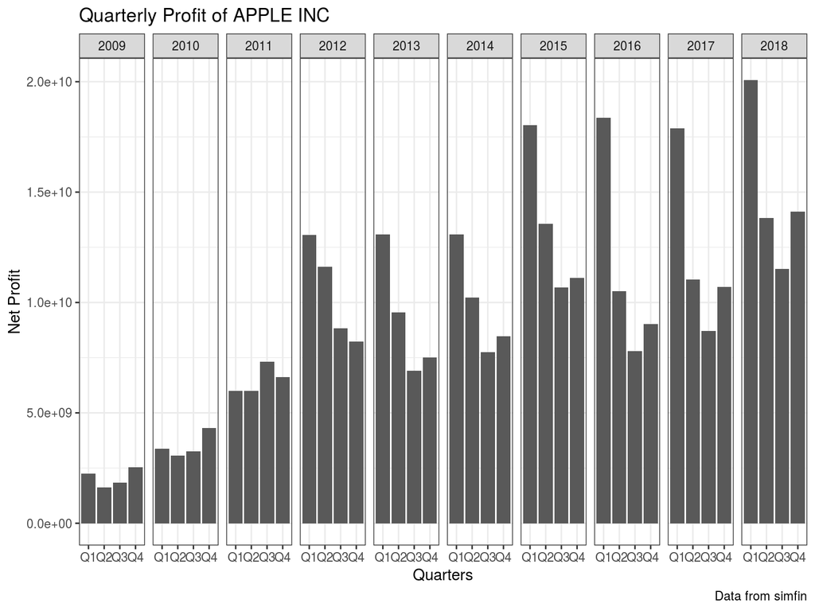

```r
net_income <- df_fin_quarters %>%
              filter(acc_name == 'Net Income')

p <- ggplot(net_income,
            aes(x = period, y = acc_value)) +
  geom_col() + facet_grid(~year, scales = 'free') +
  labs(title = 'Quarterly Profit of APPLE INC',
       x = 'Quarters',
       y = 'Net Profit',
       caption = 'Data from simfin') +
  theme_bw()

print(p)
```

Package `simfinR` can also fetch information for many companies in a single call. Let’s run another example by selecting four random companies and creating the same previous graph:

```r
set.seed(5)
my_ids <- sample(df_info_companies$simId, 4)
type_statements <- 'pl' # profit/loss
periods = 'FY' # final year
years = 2010:2018

df_fin <- simfinR_get_fin_statements(
  id_companies = my_ids,
  type_statements = type_statements,
  periods = periods,
  year = years,
  api_key = my_api_key)
```

```
## Fetching data for companies: 351460, 436223, 164920, 825113
```

```
## Fetching data for years: 2010, 2011, 2012, 2013, 2014, 2015, 2016, 2017, 2018
```

```
## Periods: FY
```

```
##
## Making sure all company ids are available
```

```
##  - all good
```

```
##
## Start grabbing data
```

```
## Fetching data for NETLIST INC (164920) | type=pl | period=FY | year=2010
```

```
##  Cant find data..
```

```
## Fetching data for NETLIST INC (164920) | type=pl | period=FY | year=2011
```

```
##  Table found. Fetching it..
```

```
## Fetching data for NETLIST INC (164920) | type=pl | period=FY | year=2012
```

```
##  Table found. Fetching it..
```

```
## Fetching data for NETLIST INC (164920) | type=pl | period=FY | year=2013
```

```
##  Table found. Fetching it..
```

```
## Fetching data for NETLIST INC (164920) | type=pl | period=FY | year=2014
```

```
##  Table found. Fetching it..
```

```
## Fetching data for NETLIST INC (164920) | type=pl | period=FY | year=2015
```

```
##  Table found. Fetching it..
```

```
## Fetching data for NETLIST INC (164920) | type=pl | period=FY | year=2016
```

```
##  Table found. Fetching it..
```

```
## Fetching data for NETLIST INC (164920) | type=pl | period=FY | year=2017
```

```
##  Table found. Fetching it..
```

```
## Fetching data for NETLIST INC (164920) | type=pl | period=FY | year=2018
```

```
##  Table found. Fetching it..
```

```
## Fetching data for ONE Gas, Inc. (351460) | type=pl | period=FY | year=2010
```

```
##  Cant find data..
```

```
## Fetching data for ONE Gas, Inc. (351460) | type=pl | period=FY | year=2011
```

```
##  Cant find data..
```

```
## Fetching data for ONE Gas, Inc. (351460) | type=pl | period=FY | year=2012
```

```
##  Table found. Fetching it..
```

```
## Fetching data for ONE Gas, Inc. (351460) | type=pl | period=FY | year=2013
```

```
##  Table found. Fetching it..
```

```
## Fetching data for ONE Gas, Inc. (351460) | type=pl | period=FY | year=2014
```

```
##  Table found. Fetching it..
```

```
## Fetching data for ONE Gas, Inc. (351460) | type=pl | period=FY | year=2015
```

```
##  Table found. Fetching it..
```

```
## Fetching data for ONE Gas, Inc. (351460) | type=pl | period=FY | year=2016
```

```
##  Table found. Fetching it..
```

```
## Fetching data for ONE Gas, Inc. (351460) | type=pl | period=FY | year=2017
```

```
##  Table found. Fetching it..
```

```
## Fetching data for ONE Gas, Inc. (351460) | type=pl | period=FY | year=2018
```

```
##  Table found. Fetching it..
```

```
## Fetching data for ANAVEX LIFE SCIENCES CORP. (436223) | type=pl | period=FY | year=2010
```

```
##  Table found. Fetching it..
```

```
## Fetching data for ANAVEX LIFE SCIENCES CORP. (436223) | type=pl | period=FY | year=2011
```

```
##  Table found. Fetching it..
```

```
## Fetching data for ANAVEX LIFE SCIENCES CORP. (436223) | type=pl | period=FY | year=2012
```

```
##  Table found. Fetching it..
```

```
## Fetching data for ANAVEX LIFE SCIENCES CORP. (436223) | type=pl | period=FY | year=2013
```

```
##  Table found. Fetching it..
```

```
## Fetching data for ANAVEX LIFE SCIENCES CORP. (436223) | type=pl | period=FY | year=2014
```

```
##  Table found. Fetching it..
```

```
## Fetching data for ANAVEX LIFE SCIENCES CORP. (436223) | type=pl | period=FY | year=2015
```

```
##  Table found. Fetching it..
```

```
## Fetching data for ANAVEX LIFE SCIENCES CORP. (436223) | type=pl | period=FY | year=2016
```

```
##  Table found. Fetching it..
```

```
## Fetching data for ANAVEX LIFE SCIENCES CORP. (436223) | type=pl | period=FY | year=2017
```

```
##  Table found. Fetching it..
```

```
## Fetching data for ANAVEX LIFE SCIENCES CORP. (436223) | type=pl | period=FY | year=2018
```

```
##  Table found. Fetching it..
```

```
## Fetching data for Daimler AG (825113) | type=pl | period=FY | year=2010
```

```
##  Table found. Fetching it..
```

```
## Fetching data for Daimler AG (825113) | type=pl | period=FY | year=2011
```

```
##  Table found. Fetching it..
```

```
## Fetching data for Daimler AG (825113) | type=pl | period=FY | year=2012
```

```
##  Table found. Fetching it..
```

```
## Fetching data for Daimler AG (825113) | type=pl | period=FY | year=2013
```

```
##  Table found. Fetching it..
```

```
## Fetching data for Daimler AG (825113) | type=pl | period=FY | year=2014
```

```
##  Table found. Fetching it..
```

```
## Fetching data for Daimler AG (825113) | type=pl | period=FY | year=2015
```

```
##  Table found. Fetching it..
```

```
## Fetching data for Daimler AG (825113) | type=pl | period=FY | year=2016
```

```
##  Table found. Fetching it..
```

```
## Fetching data for Daimler AG (825113) | type=pl | period=FY | year=2017
```

```
##  Table found. Fetching it..
```

```
## Fetching data for Daimler AG (825113) | type=pl | period=FY | year=2018
```

```
##  Cant find data..
```

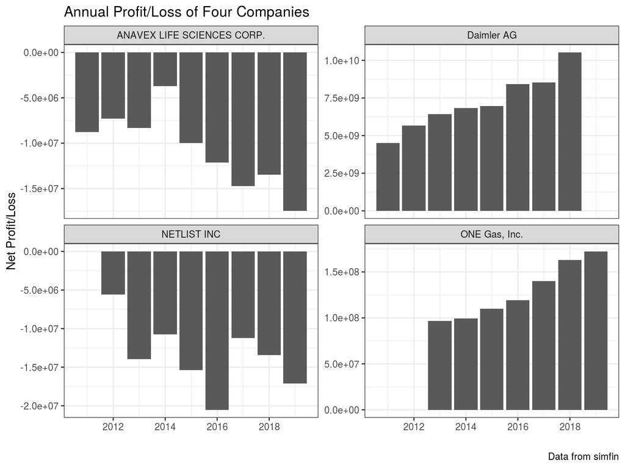

```r
net_income <- df_fin %>%
              filter(acc_name == 'Net Income')

p <- ggplot(net_income,
            aes(x = ref_date, y = acc_value)) +
  geom_col() +
  labs(title = 'Annual Profit/Loss of Four Companies',
       x = '',
       y = 'Net Profit/Loss',
       caption = 'Data from simfin') +
  facet_wrap(~company_name, scales = 'free_y') +
  theme_bw()

print(p)
```

### Example 03: Fetching price data

The simfin project also provides prices of stocks, adjusted for dividends, splits and other corporate events. Have a look:

```r
set.seed(5)
my_ids <- sample(df_info_companies$simId, 4)
type_statements <- 'pl' # profit/loss
periods = 'FY' # final year
years = 2009:2018

df_price <- simfinR_get_price_data(id_companies = my_ids,
                                   api_key = my_api_key)
```

```
## Fetching price data for 351460
```

```
## Fetching price data for 436223
```

```
## Fetching price data for 164920
```

```
## Fetching price data for 825113
```

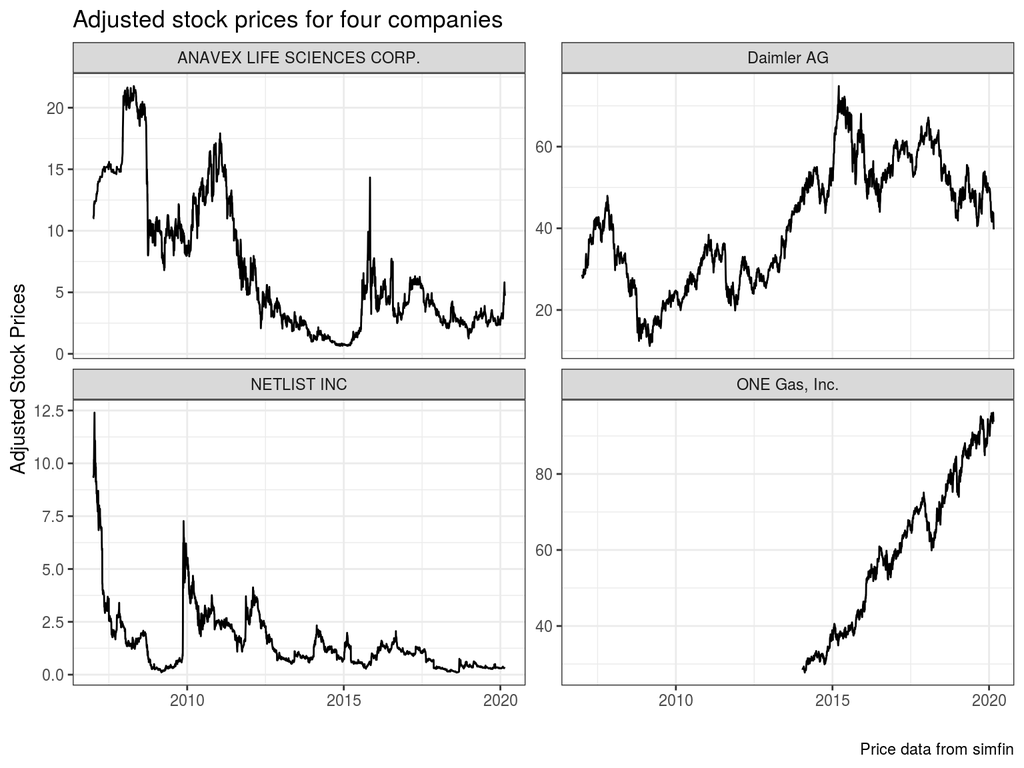

```r
p <- ggplot(df_price,
            aes(x = ref_date, y = close_adj)) +
  geom_line() +
  labs(title = 'Adjusted stock prices for four companies',
       x = '',
       y = 'Adjusted Stock Prices',
       caption = 'Price data from simfin') +
  facet_wrap(~company_name, scales = 'free_y') +
  theme_bw()

print(p)
```

As you can see, the data is comprehensive and should suffice for many different corporate finance research topics.

# Package `tidyquant`

Package `tidyquant` [@tidyquant] provides functions related to financial data acquisition and analysis. It is an ambitious project that offers many solutions in the field of finance.

Let’s look at its main functionalities. First, we will obtain price data for Apple stocks (AAPL) using function `tq_get`.

```r
library(tidyquant)
# set stock and dates
ticker <- 'AAPL'
first_date <- '2019-01-01'
last_date <-  Sys.Date()

# get data with tq_get
df_prices <- tq_get(ticker,
                    get = "stock.prices",
                    from = first_date,
                    to = last_date)

glimpse(df_prices)
```

```
## Observations: 289
## Variables: 7
## $ date     <date> 2019-01-02, 2019-01-03, 2019-01-04, 2019-01-07, 2019-01-08,…
## $ open     <dbl> 154.89, 143.98, 144.53, 148.70, 149.56, 151.29, 152.50, 152.…
## $ high     <dbl> 158.85, 145.72, 148.55, 148.83, 151.82, 154.53, 153.97, 153.…
## $ low      <dbl> 154.23, 142.00, 143.80, 145.90, 148.52, 149.63, 150.86, 151.…
## $ close    <dbl> 157.92, 142.19, 148.26, 147.93, 150.75, 153.31, 153.80, 152.…
## $ volume   <dbl> 37039700, 91312200, 58607100, 54777800, 41025300, 45099100, …
## $ adjusted <dbl> 155.2140, 139.7535, 145.7195, 145.3952, 148.1669, 150.6830, …
```

As we can see, except for column names, the price data has a similar format to the one we got with `BatchGetSymbols`. This is not surprising as both share the same origin, Yahoo Finance.

One interesting aspect of `tidyquant` is the same function, `tq_get`, can be used to download other financial information from different sources, such as Google Finance, Morning Star, FRED, and Oanda.

In the next chunk of code, we find information about all stocks traded in the NYSE (New York Securities Exchange) market.

```r
# get stocks in NYSE
df_nyse <- tq_exchange("NYSE")
```

```
## Getting data...
```

```r
glimpse(df_nyse)
```

```
## Observations: 3,098
## Variables: 7
## $ symbol          <chr> "DDD", "MMM", "WBAI", "WUBA", "EGHT", "AHC", "AOS", "…
## $ company         <chr> "3D Systems Corporation", "3M Company", "500.com Limi…
## $ last.sale.price <dbl> 10.6000, 146.8500, 4.7800, 56.0800, 20.0700, 2.6550, …
## $ market.cap      <chr> "$1.26B", "$84.53B", "$205.53M", "$8.39B", "$2.06B", …
## $ ipo.year        <dbl> NA, NA, 2013, 2013, NA, NA, NA, 2014, NA, NA, NA, NA,…
## $ sector          <chr> "Technology", "Health Care", "Consumer Services", "Te…
## $ industry        <chr> "Computer Software: Prepackaged Software", "Medical/D…
```

We find 3098 stocks for 13 sectors and 133 different industries. Notice how we could use the ticker vector with `tidyquant::tq_get` or `BatchGetSymbols` to download price data for **all stocks** traded in the NYSE exchange.

We can also get information about components of an index using function `tq_index`. The available market indices are:

```r
# print available indices
print(tq_index_options())
```

```
## [1] "DOW"       "DOWGLOBAL" "SP400"     "SP500"     "SP600"
```

Let’s get information for `"DOWGLOBAL"`.

```r
# get components of "DOWJONES"
print(tq_index("DOWGLOBAL"))
```

```
## Getting holdings for DOWGLOBAL
```

```
## # A tibble: 156 x 8
##    symbol  company   identifier sedol  weight sector  shares_held local_currency
##    <chr>   <chr>     <chr>      <chr>   <dbl> <chr>         <dbl> <chr>
##  1 AAPL    Apple In… 03783310   2046… 0.00898 Inform…        2737 USD
##  2 NG-GB   National… BDR05C     BDR0… 0.00854 Utilit…       57469 GBP
##  3 ADBE    Adobe In… 00724F10   2008… 0.00847 Inform…        2154 USD
##  4 6752-JP Panasoni… 657270     6572… 0.00843 Consum…       70905 JPY
##  5 GE      General … 36960410   2380… 0.00832 Indust…       63741 USD
##  6 NEE     NextEra … 65339F10   2328… 0.00826 Utilit…        2739 USD
##  7 NFLX    Netflix … 64110L10   2857… 0.00826 Commun…        2034 USD
##  8 MSFT    Microsof… 59491810   2588… 0.00822 Inform…        4369 USD
##  9 ROG-CH  Roche Ho… 711038     7110… 0.00811 Health…        2151 CHF
## 10 EOAN-DE E.ON SE   494290     4942… 0.00806 Utilit…       60347 EUR
## # … with 146 more rows
```

We only looked into a few functions from the package `tidyquant`. It also offers solutions for the usual manipulations, such as calculating returns and functions for portfolio analytics. You can find more details about this package in its [website](https://business-science.github.io/tidyquant/)[^5].

# Package `Rbitcoin`

Given the lasting popularity of crypto-currencies, another package worth mentioning is `RBitcoin`. It allows access to trade data from several Bitcoin exchanges. Here, let’s show a simple example of importing trade data from the `'Kraken'` exchange, using Euro as the currency.

```r
library(Rbitcoin)

# set mkt, currency pair and type of action
mkt <- "kraken"
currency <- c("BTC","EUR")
action <- 'trades'

# import data
my_l <- market.api.process(market = mkt,
                           currency_pair = currency,
                           action = action)

# print it
print(my_l)
```

```
## $market
## [1] "kraken"
##
## $base
## [1] "BTC"
##
## $quote
## [1] "EUR"
##
## $timestamp
## [1] "2020-02-26 09:02:16 -03"
##
## $market_timestamp
## [1] NA
##
## $trades
##                      date  price     amount                 tid type
##    1: 2020-02-26 11:13:30 8420.0 0.25000000                <NA>  bid
##    2: 2020-02-26 11:13:30 8423.1 0.00970000                <NA>  bid
##    3: 2020-02-26 11:13:30 8424.6 0.11262634                <NA>  bid
##    4: 2020-02-26 11:13:34 8423.9 0.00236880                <NA>  bid
##    5: 2020-02-26 11:13:38 8420.3 0.04987034                <NA>  ask
##   ---
##  996: 2020-02-26 12:02:10 8422.9 0.06774549                <NA>  bid
##  997: 2020-02-26 12:02:10 8422.9 0.04018537                <NA>  bid
##  998: 2020-02-26 12:02:11 8422.9 0.17869000                <NA>  bid
##  999: 2020-02-26 12:02:13 8422.9 0.11841607                <NA>  bid
## 1000: 2020-02-26 12:02:15 8422.9 0.00223610 1582718535717342255  bid
```

The output of `market.api.process` is a `list` object with information about Bitcoin in the `'Kraken'` market. The actual trades are available in the `trade` slot of `my_l`. Let’s have a look at its content:

```r
glimpse(my_l$trades)
```

```
## Observations: 1,000
## Variables: 5
## $ date   <dttm> 2020-02-26 11:13:30, 2020-02-26 11:13:30, 2020-02-26 11:13:30…
## $ price  <dbl> 8420.0, 8423.1, 8424.6, 8423.9, 8420.3, 8420.3, 8420.3, 8424.3…
## $ amount <dbl> 0.25000000, 0.00970000, 0.11262634, 0.00236880, 0.04987034, 0.…
## $ tid    <chr> NA, NA, NA, NA, NA, NA, NA, NA, NA, NA, NA, NA, NA, NA, NA, NA…
## $ type   <chr> "bid", "bid", "bid", "bid", "ask", "ask", "ask", "bid", "bid",…
```

It includes price and time information for the past 1000 trades. The package also includes functions for looking into the order book of each market and managing Bitcoin wallets. One can find more details about the functionalities of the package in its [website](https://github.com/jangorecki/Rbitcoin)[^6].

# Other Packages

In CRAN, you’ll find many more packages for importing financial datasets in R. In this section, we focused on packages, which are free and easy to use. Interface with commercial data sources is also possible. Several companies provide APIs for serving data to their clients. Packages such as `Rblpapi` (Bloomberg), `IBrokers` (Interactive Brokers), `TFX` (TrueFX), `rdatastream` (Thomson Dataworks) can make R communicate with these commercial platforms. If the company you use is not presented here, check the [list of packages in CRAN](https://cran.r-project.org/)[^7]. It is very likely you’ll find what you need.

# Exercises

1. Using the `BatchGetSymbols` package, download price data for Tesla, Inc. (TSLA) in the last two years. What is the lowest adjusted price you can find? What is the date with the lowest price? Tip: Use function `which.min` to find the position of the minimum price.
2. Use `tidyquant::tq_get` to download historical values for the SP500 index (^GSPC) since 1950 until today. What is the annual compound rate of return for the index?
3. Use the [Quandl search box](https://www.quandl.com/search)[^8] to find available databases for your country. This includes databases from Central Banks and research agencies. Cite those that are most popular and most likely to be used in your work.
4. Create a profile on the [Quandl website](https://www.quandl.com/)[^9]. Using `GetQuandlData`, download unemployment data for Brazil using the Central Bank of Brazil Statistical Database. What is the latest value of this series?
5. What is the latest value of EUR Bitcoin at BTC? Use trade price data information from the `Kraken` exchange to solve the exercise.
[^1]: https://simfin.com/
[^2]: https://www.quandl.com/
[^3]: https://simfin.com/
[^4]: https://simfin.com/data/access/api
[^5]: https://business-science.github.io/tidyquant/
[^6]: https://github.com/jangorecki/Rbitcoin
[^7]: https://cran.r-project.org/
[^8]: https://www.quandl.com/search
[^9]: https://www.quandl.com/